# Introduction to R: One-Way ANOVA

First steps in statistical modeling in R (July 2020)

# 1 Introduction

## 1.1 Slides, code and tutorials

This chapter of the interactive book contains all R code that was used to produce the results and output presented in chapter 3 (modeling :one way ANOVA) in the course’s slides. We include YouTube tutorials as a part of the book chapter and links to the relevant tutorials are provided. Note that these tutorials were not developed especially for this book, they cover the same topics using different examples.

## 1.2 R ?

No previous knowledge about R is required. We use the R function `aov()` to fit a One-Way ANOVA in R and the chicken Weights dataset is used for illustraion. The same model can be fitted using the functions `lm()` and `glm()` as well.

## 1.3 Slides

Slide for this part of the course are avilable online in the >eR-BioStat website. See [Rcoursemodeling](https://github.com/eR-Biostat/Courses/blob/master/Introductory%20Courses/Introduction%20to%20R/Slides/eR-Biostat_An%20Introduction%20to%20R_2017_Modeling1.pdf).

# 2 The Chicken Weights data

For illustrations, we use the Chicken Weights data. Newly hatched chicks were randomly allocated into six groups, and each group was given a different feed supplement. Their weights (the response variable) in grams after six weeks are given along with feed types (the factor). The Chicken Weights data is a data frame in R called `chickwts` is shown below.

```r
head(chickwts)
```

```
##   weight      feed
## 1    179 horsebean
## 2    160 horsebean
## 3    136 horsebean
## 4    227 horsebean
## 5    217 horsebean
## 6    168 horsebean
```

# 3 One-Way ANOVA model

## 3.1 YouTube tutorials: One-Way ANOVA in R

### 3.1.1 R - One-way ANOVA

For a YouTube tutorial about One-Way ANOVA in R R Statistics and Research see [YTOneWayANOVA1](https://www.youtube.com/watch?v=4DeCaCaC2JQ).

### 3.1.2 One way ANOVA in RStudio

For a YouTube tutorial about One-Way ANOVA by Tom Sherrattin R see [YTOneWayANOVA2](https://www.youtube.com/watch?v=zDGQxC0bWn4).

## 3.2 Model formulation

We consider a one-way ANOVA model for that data

Our primary of interest is to estimate the group means and then to test the hypotheses
$$\begin{array}{l}
\mbox{H}_{0}:\mu_{1}=\mu_{2}=\dots=\mu_{6},\\
\mbox{H}_{1}: \mu_{l} \ne \mu_{k}\;\;\mbox{for at least one pair}.
\end{array}$$

## 3.3 Visualizing the Data

The striptplot in Figure~3.1 shows the chickens’ weight by diet group.

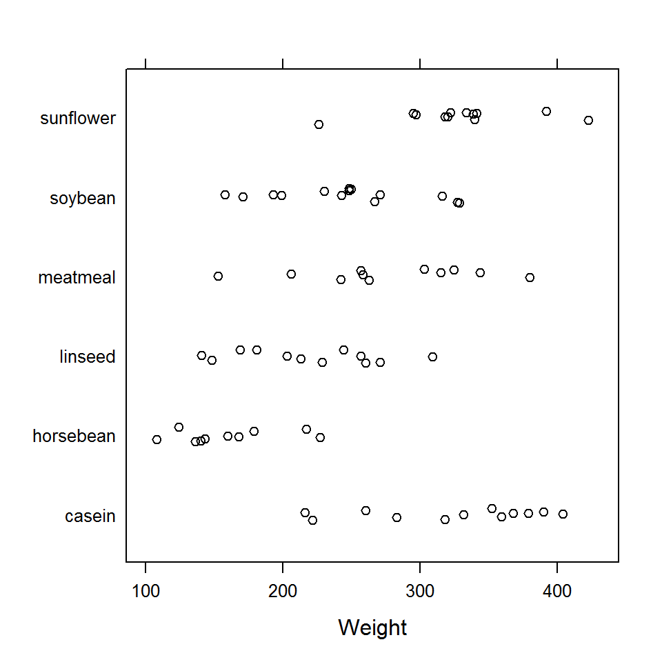

Figure 3.1: Chicks weight by diet group.

```r
stripplot(feed ~ jitter(weight),
            data = chickwts,
            aspect = 1, jitter = T,
            xlab="Weight", col = 1)
```

The boxplot in Figure~3.2 can be used to visualize the patterns in the data. Note how the box of the horsebean diet group located lower than the boxes of the other diet groups.

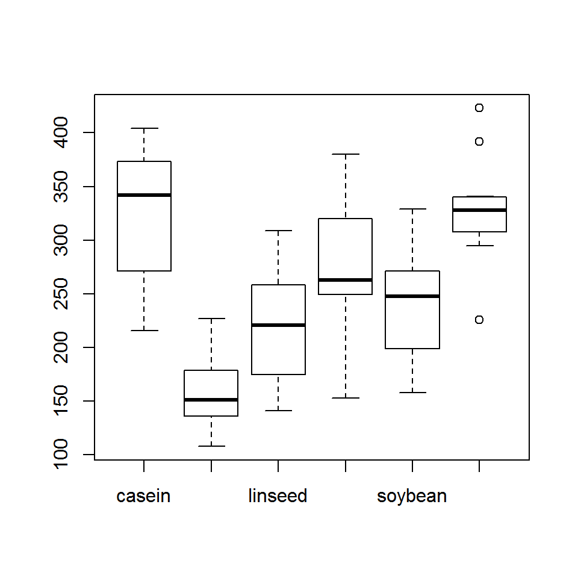

Figure 3.2: Chicks weight by diet group.

```r
boxplot(split(chickwts$weight,chickwts$feed))
```

The sample means for the 6 diet groups are equal to

```r
 tapply(chickwts$weight,chickwts$feed,mean)
```

```
##    casein horsebean   linseed  meatmeal   soybean sunflower
##  323.5833  160.2000  218.7500  276.9091  246.4286  328.9167
```

# 4 Fitting a One-way ANOVA Model in R

## 4.1 The `aov()` Function

The R function which we use to fit a One-way ANOVA model in R is `aov()`. A General call of the function has the form of `aov(dependent variable~factor)`. For example, a one-way ANOVA model for the response `y` and the factor `x` can be fitted using `aov(y~x)`. If `x` is a numerical vector, we can use `aov(y~as.factor(x))`.

## 4.2 Fitting an ANOVA Modelfor the Chicken Weights data

In order to fit the model
$$Y_{ij}=\mu_{i}+\varepsilon_{ij},$$

we use

```r
Fit.aov<-aov(chickwts$weight~chickwts$feed)
```

the object `Fit.aov` contains the results. The ANOVA table can be produced using the function `summary()` and it is given by:

```r
 summary(Fit.aov)
```

```
##               Df Sum Sq Mean Sq F value   Pr(>F)
## chickwts$feed  5 231129   46226   15.37 5.94e-10 ***
## Residuals     65 195556    3009
## ---
## Signif. codes:  0 '***' 0.001 '**' 0.01 '*' 0.05 '.' 0.1 ' ' 1
```

# 5 Diagnostic Plots

## 5.1 Residuals

The object `Fit.aov$resid` contains the residuals values.

```r
Fit.aov$resid
```

```
##           1           2           3           4           5           6           7           8
##   18.800000   -0.200000  -24.200000   66.800000   56.800000    7.800000  -52.200000  -36.200000
##           9          10          11          12          13          14          15          16
##  -17.200000  -20.200000   90.250000   10.250000  -37.750000  -77.750000   41.250000  -15.750000
##          17          18          19          20          21          22          23          24
##  -70.750000  -49.750000   -5.750000   38.250000   25.250000   52.250000   -3.428571  -16.428571
##          25          26          27          28          29          30          31          32
##    1.571429   80.571429   82.571429    3.571429  -53.428571   24.571429   69.571429   20.571429
##          33          34          35          36          37          38          39          40
##  -47.428571  -75.428571  -88.428571    1.571429   94.083333   11.083333   63.083333   10.083333
##          41          42          43          44          45          46          47          48
##   12.083333 -102.916667   -8.916667  -33.916667    5.083333   -6.916667  -31.916667  -10.916667
##          49          50          51          52          53          54          55          56
##   48.090909  -19.909091   26.090909   38.090909  103.090909 -123.909091  -13.909091  -34.909091
##          57          58          59          60          61          62          63          64
##  -70.909091   67.090909  -18.909091   44.416667   66.416667   55.416667  -63.583333   80.416667
##          65          66          67          68          69          70          71
##   -5.583333   28.416667   35.416667 -107.583333 -101.583333  -40.583333    8.416667
```

A Stem-and-leaf diagram reveals a symatical distribution of the residuals.

```r
stem(Fit.aov$resid)
```

```
##
##   The decimal point is 1 digit(s) to the right of the |
##
##   -12 | 4
##   -10 | 832
##    -8 | 8
##    -6 | 85114
##    -4 | 32071
##    -2 | 86542400
##    -0 | 976641976630
##     0 | 22458800129
##     2 | 15568588
##     4 | 148257
##     6 | 36770
##     8 | 01304
##    10 | 3
```

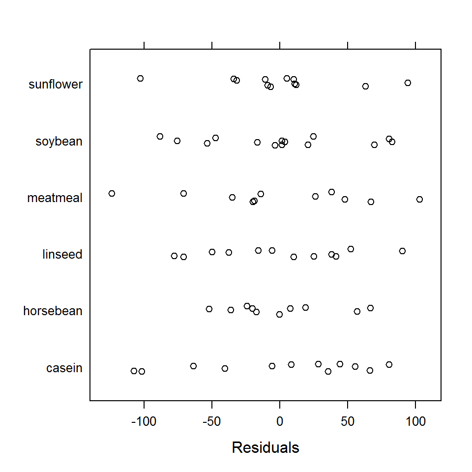

Figure 5.1: Residuals by diet group.

```r
stripplot(chickwts$feed ~ jitter(Fit.aov$resid), aspect = 1, jitter = T, xlab =
    "Residuals", col = 1)
```

Boxplot, histogram and normal probability plot for the residuals are shown in Figure ~5.2.

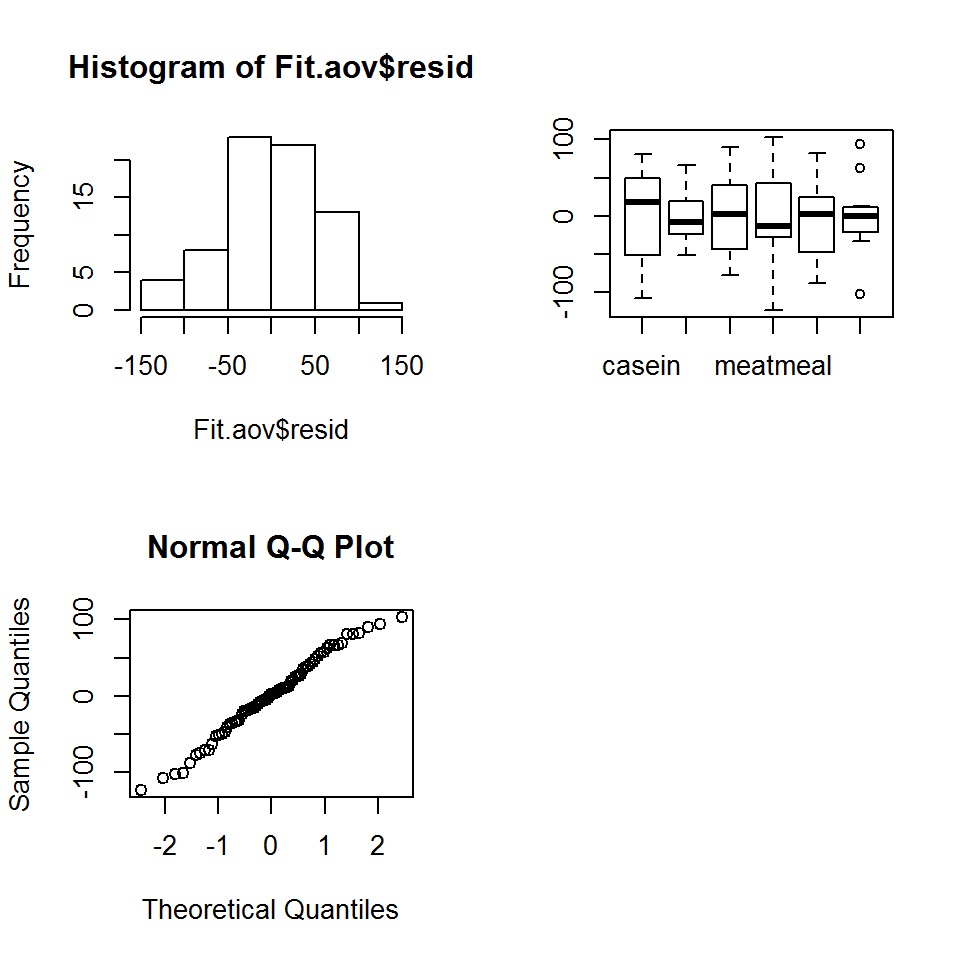

Figure 5.2: Distribution for the residuals.

```r
par(mfrow = c(2, 2))
hist(Fit.aov$resid)
boxplot(split(Fit.aov$resid, chickwts$feed))
qqnorm(Fit.aov$resid)
```

Alternativly, these figures can be produce using the function `plot()` in the following way

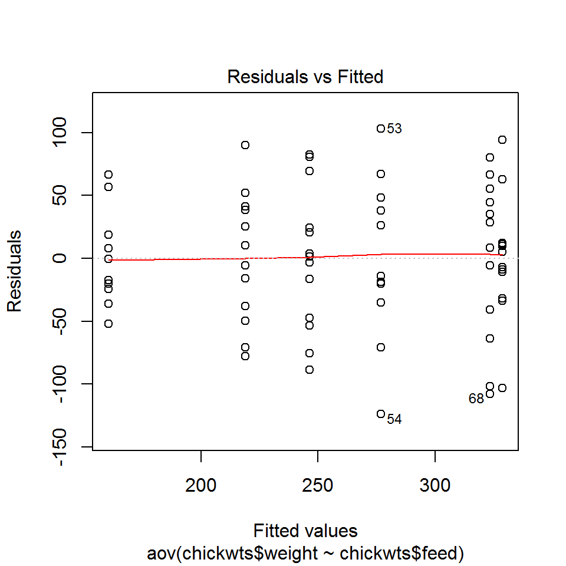

Figure 5.3: Diagnostic plots.

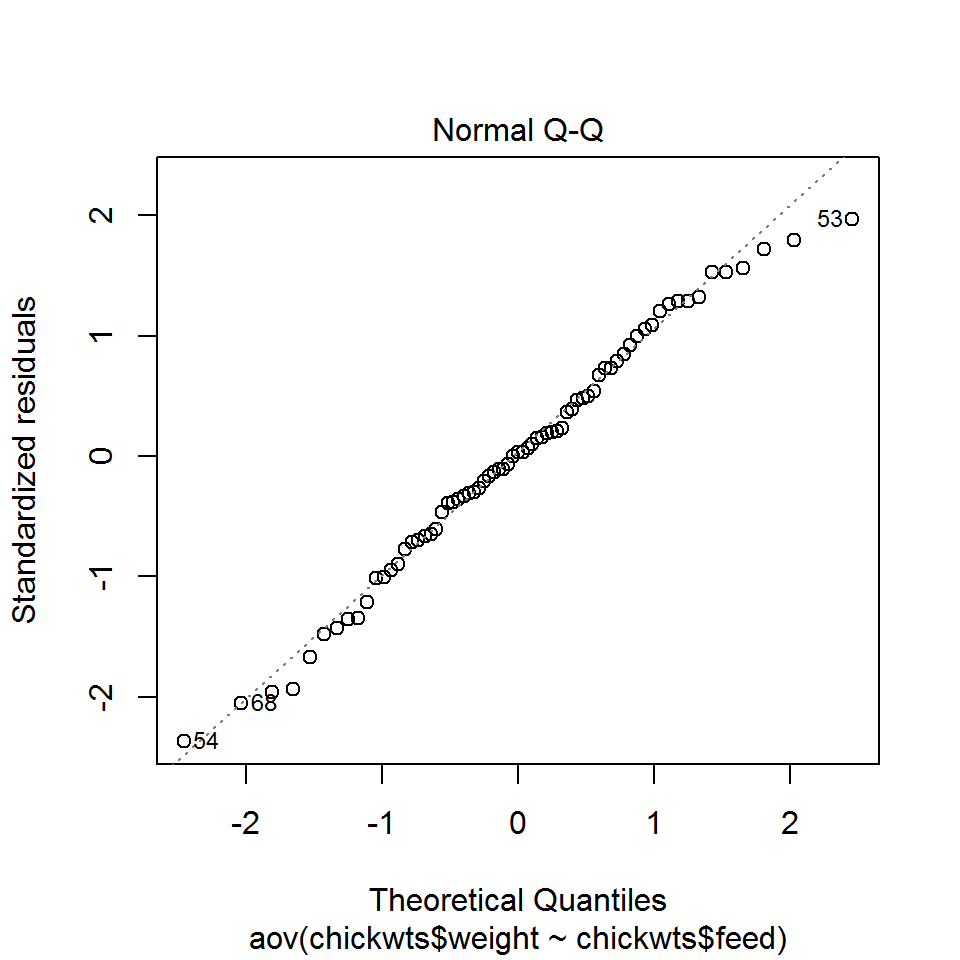

Figure 5.4: Diagnostic plots.

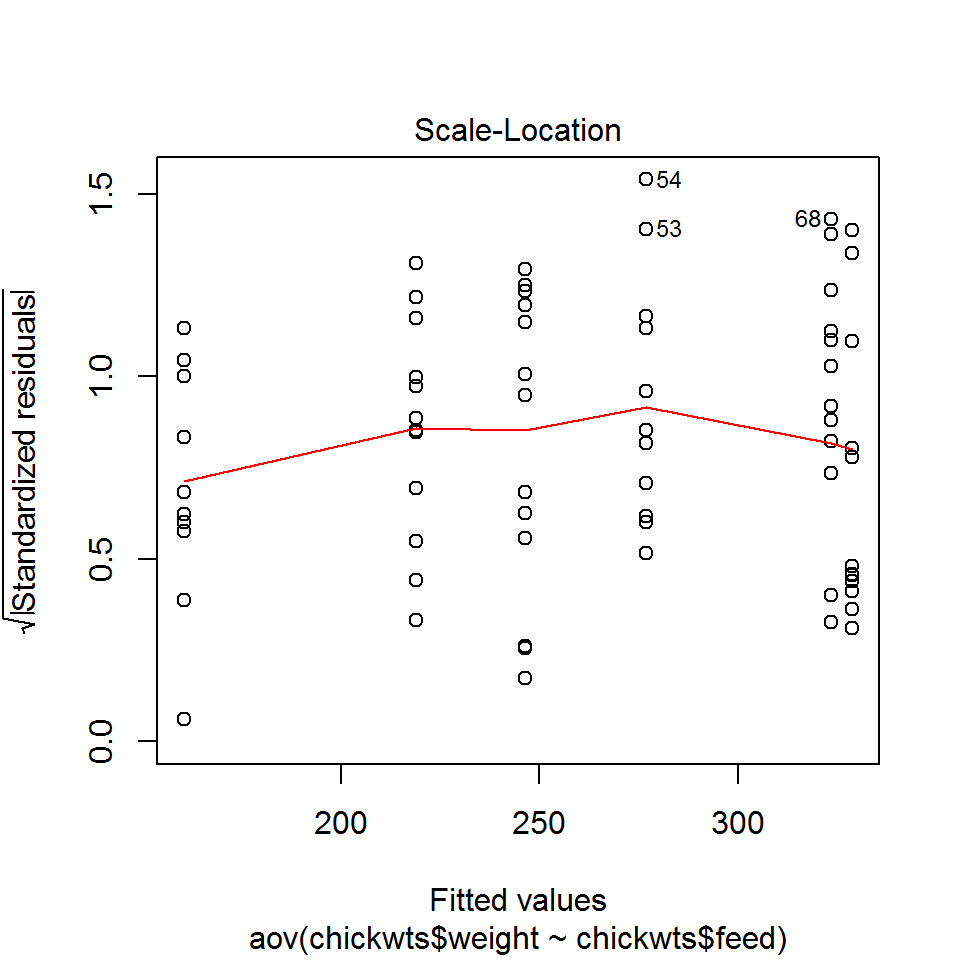

Figure 5.5: Diagnostic plots.

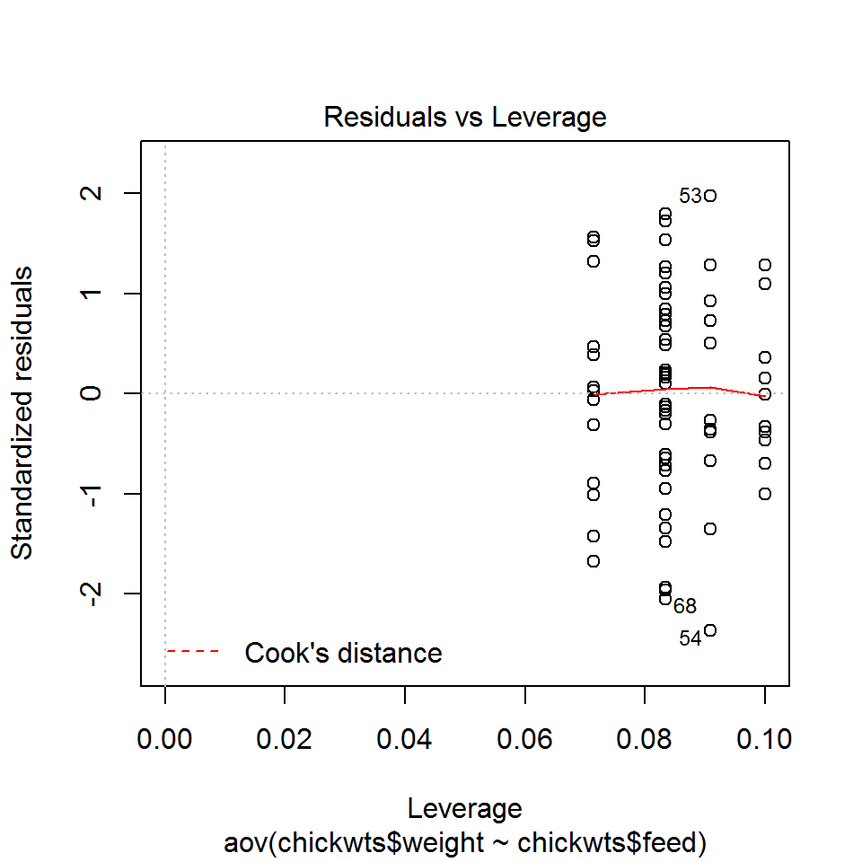

Figure 5.6: Diagnostic plots.

```r
plot(Fit.aov)
```

Ziv Shkedy  
Hasselt University, Belgium

July, 2020